# Report on exploration of data preparation

Valeria

7/27/2020

**TO DO**:

- remove experiment with pooled sex.
- filter meta-analysis for cFos
- Valeria:
  1. contact publication van Hasselt et al. for summary statistics
  2. contact publication Wang et al. for sex of the animals

# Descriptives

The data was downloaded as excel file *“data/raw/outcomes.xlsx”* from osf. Then, this was processed in *“src/data_preparation.R”*. The output *“data/temp/df_report_datapreparation.R”* is here analyzed for descriptives.

**ATTENTION**: the results have been blinded.

## Papers, experiments, animals

29 publications met our pre-specified inclusion criteria: these used >3289 animals (rats = 80.05%) from 53 experiments. 7 effect sizes are missing. Missing variances have been imputed by adding the **median** (Heike did mean). These come all from the same publication (van Hasselt et al.).

17 experiments used females, 34 experiments used males. 1 had pulled sex and in 1 experiment sex was not specified. The experiment in which sex was not specified will be removed for the analysis. Males and females are analyzed separately as we interpret them as two different biological systems. Studies with pooled sexes will be contextualized at a systematic review level.

The distribution across outcomes of the effect sizes extracted, can be investigated here below. cFos was the most studied ieg (93.07% of extracted effect sizes). Only cFos will be meta-analyzed, whereas the other IEGs will be contextualized with systematic review.

```
## # A tibble: 4 x 4
##   iegName  obvs   exp  publ
##   <chr>   <int> <int> <int>
## 1 Arc        11     3     3
## 2 cFos      215    49    25
## 3 dFosB       1     1     1
## 4 Egr1        4     1     1
```

## cFos: meta-analysis choices

The “data_onefile.R” from the “data_preparation.R” is filtered for sex (NS excluded) and ieg (only cFos). A total of 208 are included (males: 70.19 %), 0 effect sizes are missing.

### Choosing moderators for meta-analysis based on frequency

Important variables to consider:

- sex
  - NS excluded, P systematic review, M and F separately
- species
  - F: exploratory subgroup analysis
  - M: sensitivity analysis on rats
- model (and timing of model)
  - sensitivity analysis on MS
    - females have only MS
    - M: sensitivity on MS
- second hit
  - moderator or subgroup
- acute stressor (presence, time, novelty, refractory period)
  - presence: moderator
  - type: needs to be subgrouped
  - novelty: exploratory subgroup analysis
  - time: exploratory meta-regression in males
- outcome (type and technique)
  - type:
    - F: sensitivity on proteins
    - M: subgroup
- brain area
  - moderator
  - F: PFC only from 2 independent publications >> *exclude?*

```
## # A tibble: 4 x 5
## # Groups:   sex [2]
##   sex   species  obvs   exp  publ
##   <chr> <chr>   <int> <int> <int>
## 1 F     mice       29     5     2
## 2 F     rat        33    12     7
## 3 M     mice       11     3     3
## 4 M     rat       135    28    16
## # A tibble: 4 x 5
## # Groups:   sex [2]
##   sex   model  obvs   exp  publ
##   <chr> <chr> <int> <int> <int>
## 1 F     MS       62    17     9
## 2 M     LBN       1     1     1
## 3 M     LG        9     1     1
## 4 M     MS      136    29    17
## # A tibble: 4 x 5
## # Groups:   sex [2]
##   sex   hit2   obvs   exp  publ
##   <chr> <fct> <int> <int> <int>
## 1 F     0        23     9     6
## 2 F     1        39     8     6
## 3 M     0        69    12    11
## 4 M     1        77    19    11
## # A tibble: 4 x 5
## # Groups:   sex [2]
##   sex   tAcuteStressor  obvs   exp  publ
##   <chr> <fct>          <int> <int> <int>
## 1 F     0                 20     9     5
## 2 F     1                 42     8     6
## 3 M     0                 51    12     9
## 4 M     1                 95    19    16
## # A tibble: 20 x 5
## # Groups:   sex [2]
##    sex   tStressorType                     obvs   exp  publ
##    <chr> <fct>                            <int> <int> <int>
##  1 F     DLB                                  4     1     1
##  2 F     FST                                  4     1     1
##  3 F     MWM                                 14     2     1
##  4 F     NA                                  20     9     5
```

[output cut: 43 more lines]

```
## 6 M     qPCR             7     1     1
## # A tibble: 10 x 5
## # Groups:   sex [2]
##    sex   areaLevel2  obvs   exp  publ
##    <chr> <fct>      <int> <int> <int>
##  1 F     AMY           17     7     3
##  2 F     HPF           12     5     3
##  3 F     HYP           13    13     7
##  4 F     PFC            9     3     2
##  5 F     TH            11     9     5
##  6 M     AMY           27    16     9
##  7 M     HPF           40    10     7
##  8 M     HYP           32    19    11
##  9 M     PFC           34    10     6
## 10 M     TH            13     7     4
```

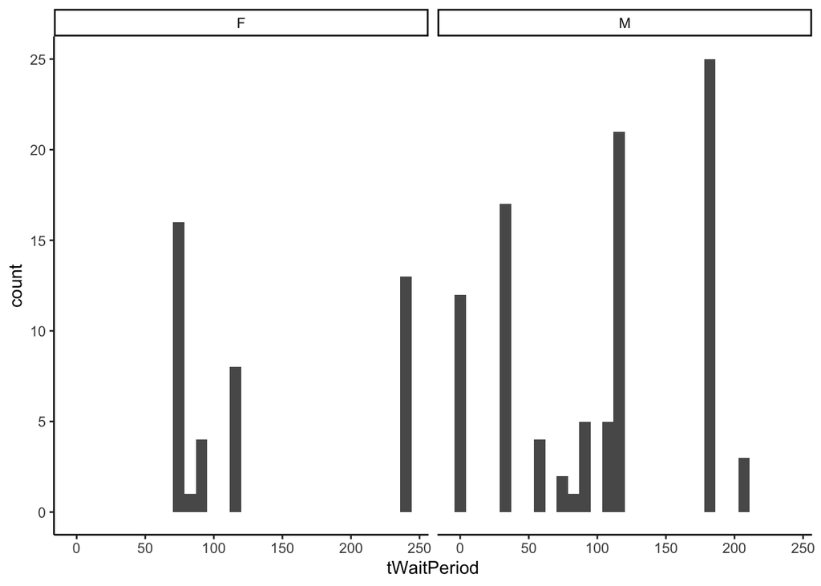

### Analyses: CHECK WITH HEIKE

From the frequency exploration above, the following variables have been selected for *moderators*:

- brain area (**areaLevel2**)
- baseline or after acute stress (**tAcuteStressor**)

The following variables have been selected for *subgroup analysis*:

- presence of multiple hits (**hit2**)
- species (**species**)

The following variables will be used for *exploratory subgroup analysis*:

- acute stressor
  - type (grouped)
  - novelty
  - time
- protein vs RNA (in males)

*Sensitivity analysis* will be conducted on:

- blinded and randomized papers
- model (MS)

*Other choices*:

- PFC papers in females will be included in the overall analysis, but no specific PFC analysis will be conducted.